# Design declaration, diagnosis, and redesign

MIDA and more

Graeme Blair, Alex Coppock, Macartan Humphreys

# 1 `DeclareDesign`: A deeper dive

## 1.1 Steps in an experimental design

We start with a simple experimental design with all four elements of MIDA and then show ways to extend.

- Variations to *M* and *I* are supported by the `fabricatr` package (and others)
- Variations to *D* are supported by the `randomizr` package (and others)
- Variations to *A* are supported by the `estimatr` package (and others)

### 1.1.1 A simple experimental design

```r
N <- 100
b <- .5

design <-
  declare_model(N = N, U = rnorm(N),
                potential_outcomes(Y ~ b * Z + U)) +
  declare_assignment(Z = simple_ra(N), Y = reveal_outcomes(Y ~ Z)) +
  declare_inquiry(ate = mean(Y_Z_1 - Y_Z_0)) +
  declare_estimator(Y ~ Z, inquiry = "ate", .method = lm_robust)
```

New elements:

- `declare_model` can be used much like `mutate` with multiple columns created in sequence
- the `potential_outcomes` function is a special function that creates potential outcome columns for different values of `Z`
- when you assign a treatment that affects an outcome you can use `reveal_outcome` to reveal the outcome; `Z` and `Y` are default names
- when you declare an estimator you should normally include a label, specify an inquiry, and provide the method to be used (`lm_robust` is default)

### 1.1.2 Steps: Order matters

e.g. If you sample before defining the inquiry you get a different inquiry to if you sample after you define the inquiry

```r
design_1 <-
  declare_model(N = 1000, X = rep(0:1, N/2), Y = X + rnorm(N)) +
  declare_sampling(S= strata_rs(strata = X, strata_prob = c(.2, .8))) +
  declare_inquiry(m = mean(Y))

design_1 |> draw_estimands()
```

```
  inquiry  estimand
1       m 0.7606704
```

### 1.1.3 Steps: Order matters

e.g. If you sample before defining the inquiry you get a different inquiry to if you sample after you define the inquiry

```r
design_2 <-
  declare_model(N = 1000, X = rep(0:1, N/2), Y = X + rnorm(N)) +
  declare_inquiry(m = mean(Y)) +
  declare_sampling(S= strata_rs(strata = X, strata_prob = c(.2, .8)))

design_2 |> draw_estimands()
```

```
  inquiry  estimand
1       m 0.4957891
```

## 1.2 M: Key extensions to model declaration

### 1.2.1 Hierarchical data

You can generate hierarchical data like this:

```r
M <-
  declare_model(
    households = add_level(
      N = 100,
      N_members = sample(c(1, 2, 3, 4), N,
                         prob = c(0.2, 0.3, 0.25, 0.25), replace = TRUE)
    ),
    individuals = add_level(
      N = N_members,
      age = sample(18:90, N, replace = TRUE)
    )
  )
```

### 1.2.2 Hierarchical data

You can generate hierarchical data like this:

```r
M() |> head() |> kable(digits = 2) |> kable_styling(font_size = 20)
```

| households | N_members | individuals | age |
| --- | --- | --- | --- |
| 001 | 1 | 001 | 79 |
| 002 | 2 | 002 | 69 |
| 002 | 2 | 003 | 19 |
| 003 | 3 | 004 | 21 |
| 003 | 3 | 005 | 37 |
| 003 | 3 | 006 | 64 |

### 1.2.3 Panel data

You can generate panel data like this:

```r
M <-
  declare_model(
    countries = add_level(
      N = 196,
      country_shock = rnorm(N)
    ),
    years = add_level(
      N = 100,
      time_trend = 1:N,
      year_shock = runif(N, 1, 10),
      nest = FALSE
    ),
    observation = cross_levels(
      by = join_using(countries, years),
      observation_shock = rnorm(N),
      Y = 0.01 * time_trend + country_shock + year_shock + observation_shock
    )
  )
```

### 1.2.4 Panel data

You can generate panel data like this:

```r
M() |> head() |> kable(digits = 2) |> kable_styling(font_size = 20)
```

| countries | country_shock | years | time_trend | year_shock | observation | observation_shock | Y |
| --- | --- | --- | --- | --- | --- | --- | --- |
| 001 | 0.39 | 001 | 1 | 4.66 | 00001 | -1.40 | 3.66 |
| 002 | 0.09 | 001 | 1 | 4.66 | 00002 | 0.18 | 4.95 |
| 003 | -1.85 | 001 | 1 | 4.66 | 00003 | 0.75 | 3.58 |
| 004 | -1.92 | 001 | 1 | 4.66 | 00004 | -2.06 | 0.69 |
| 005 | -0.11 | 001 | 1 | 4.66 | 00005 | 1.13 | 5.69 |
| 006 | 0.07 | 001 | 1 | 4.66 | 00006 | 0.88 | 5.63 |

### 1.2.5 Preexisting data

```r
M <-
  declare_model(
    data = baseline_data,
    attitudes = sample(1:5, N, replace = TRUE)
  )
```

### 1.2.6 Steps

You can repeat steps and play with the order, always conscious of the direction of the pipe

```r
design <-
  declare_model(N = N, X = rep(0:1, N/2)) +
  declare_model(U = rnorm(N), potential_outcomes(Y ~ b * Z * X + U)) +
  declare_assignment(Z = block_ra(blocks = X), Y = reveal_outcomes(Y ~ Z)) +
  declare_inquiry(ate = mean(Y_Z_1 - Y_Z_0)) +
  declare_inquiry(cate = mean(Y_Z_1[X==0] - Y_Z_0[X==0])) +
  declare_estimator(Y ~ Z, inquiry = "ate", label = "ols") +
  declare_estimator(Y ~ Z*X, inquiry = "cate", label = "fe")
```

### 1.2.7 You can generate multiple columns together

```r
M2 <-
  declare_model(
    draw_multivariate(c(X1, X2) ~ MASS::mvrnorm(
      n = 1000,
      mu = c(0, 0),
      Sigma = matrix(c(1, 0.3, 0.3, 1), nrow = 2)
    )))
```

### 1.2.8 You can generate multiple columns together

```r
M2() |> head() |> kable(digits = 2) |> kable_styling(font_size = 28)
```

| X1 | X2 |
| --- | --- |
| 0.42 | -0.70 |
| 1.54 | 0.28 |
| -0.62 | -0.35 |
| -0.60 | 0.07 |
| 0.79 | 0.79 |
| 0.84 | 0.96 |

### 1.2.9 Cluster structures with cluster correlations

```r
M <-
  declare_model(households = add_level(N = 1000),
                individuals = add_level(
                  N = 4,
                  X = draw_normal_icc(
                    mean = 0,
                    clusters = households,
                    ICC = 0.65
                  )
                ))
```

### 1.2.10 Cluster structures with cluster correlations

```r
model <- lm_robust(X ~ households, data = M())
model$adj.r.squared
```

```
[1] 0.6215795
```

## 1.3 I: Inquiries

### 1.3.1 Inquiries using predefined potential outcomes

Many causal inquiries are simple summaries of potential outcomes:

| Inquiry | Units | Code |
| --- | --- | --- |
| Average treatment effect in a finite population (PATE) | Units in the population | `mean(Y_D_1 - Y_D_0)` |
| Conditional average treatment effect (CATE) for X = 1 | Units for whom X = 1 | `mean(Y_D_1[X == 1] - Y_D_0[X == 1])` |
| Complier average causal effect (CACE) | Complier units | `mean(Y_D_1[D_Z_1 > D_Z_0] - Y_D_0[D_Z_1 > D_Z_0])` |
| Causal interactions of $D_1$ and $D_2$ | Units in the population | `mean((Y_D1_1_D2_1 - Y_D1_0_D2_1) - (Y_D1_1_D2_0 - Y_D1_0_D2_0))` |

Generating potential outcomes columns gets you far

### 1.3.2 Inquiries using functions

Often though we need to define inquiries as a function of continuous variables. For this generating a potential outcomes function can make life easier. This helps for:

- Continuous quantities
- Spillover quantities
- Complex counterfactuals

### 1.3.3 Complex counterfactuals

Here is an example of using functions to define complex counterfactuals:

```r
f_M <- function(X, UM) 1*(UM < X)
f_Y <- function(X, M, UY) X + M - .4*X*M + UY

design <-
  declare_model(N = 100,
                X = simple_rs(N),
                UM = runif(N),
                UY = rnorm(N),
                M = f_M(X, UM),
                Y = f_Y(X, M, UY)) +
  declare_inquiry(Q1 = mean(f_Y(1, f_M(0, UM), UY) - f_Y(0, f_M(0, UM), UY)))

design |> draw_estimands() |> kable() |> kable_styling(font_size = 20)
```

| inquiry | estimand |
| --- | --- |
| Q1 | 1 |

### 1.3.4 Complex counterfactuals

Here is an example of using functions to define effects of continuous treatments.

```r
f_Y <- function(X, UY) X - .25*X^2 + UY

design <-
  declare_model(N = 100,
                X  = rnorm(N),
                UY = rnorm(N),
                Y = f_Y(X, UY)) +
  declare_inquiry(
    Q1 = mean(f_Y(X+1, UY) - f_Y(X, UY)),
    Q2 = mean(f_Y(1, UY) - f_Y(0, UY)),
    Q3 = (lm_robust(Y ~ X)|> tidy())[2,2]
    )

design |> draw_estimands() |> kable() |> kable_styling(font_size = 20)
```

| inquiry | estimand |
| --- | --- |
| Q1 | 0.7237174 |
| Q2 | 0.7500000 |
| Q3 | 1.2303680 |

which one is the ATE?

## 1.4 D

### 1.4.1 Assignment schemes

The `randomizr` package has a set of functions for different types of block and cluster assignments.

- Simple random assignment: “Coin flip” or Bernoulli random assignment. All units have the same probability of assignment: `simple_ra(N = 100, prob = 0.25)`
- Complete random assignment: Exactly m of N units are assigned to treatment, and all units have the same probability of assignment m/N `complete_ra(N = 100, m = 40)`

### 1.4.2 Assignment schemes

- Block random assignment: Complete random assignment within pre-defined blocks. Units within the same block have the same probability of assignment $m_b / N_b$: `block_ra(blocks = regions)`
- Cluster random assignment: Whole groups of units are assigned to the same treatment condition. `cluster_ra(clusters = households)` * Block-and-cluster assignment: Cluster random assignment within blocks of clusters `block_and_cluster_ra(blocks = regions, clusters = villages)`

### 1.4.3 Assignment schemes

You can combine these in various ways. For examples with saturation random assignment first clusters are assigned to a saturation level, then units within clusters are assigned to treatment conditions according to the saturation level:

```r
saturation = cluster_ra(clusters = villages,
                        conditions = c(0, 0.25, 0.5, 0.75))

block_ra(blocks = villages, prob_unit = saturation)
```

## 1.5 A

### 1.5.1 A: Answers: terms

By default `declare_estimates()` assumes you are interested in the *first term after the constant* from the output of an estimation procedure.

But you can say what you are interested in directly using `term` and you can also associate different terms with different quantities of interest using `inquiry`.

```r
design <-
  declare_model(
    N = 100,
    X1 = rnorm(N),
    X2 = rnorm(N),
    X3 = rnorm(N),
    Y = X1 - X2 + X3 + rnorm(N)
  ) +
  declare_inquiries(ate_2 = -1, ate_3 = 1) +
  declare_estimator(Y ~ X1 + X2 + X3,
                    term = c("X2", "X3"),
                    inquiry = c("ate_2", "ate_3"))

design  |> run_design()  |> kable(digits = 2) |> kable_styling(font_size = 20)
```

| inquiry | estimand | term | estimator | estimate | std.error | statistic | p.value | conf.low | conf.high | df | outcome |
| --- | --- | --- | --- | --- | --- | --- | --- | --- | --- | --- | --- |
| ate_2 | -1 | X2 | estimator | -0.94 | 0.13 | -7.36 | 0 | -1.19 | -0.69 | 96 | Y |
| ate_3 | 1 | X3 | estimator | 0.96 | 0.11 | 9.09 | 0 | 0.75 | 1.17 | 96 | Y |

### 1.5.2 A: Answers: terms

Sometimes it can be confusing what the names of a term is but you can figure this by running the estimation strategy directly. Here’s an example where the names of a term might be confusing.

```r
lm_robust(Y ~ A*B,
          data = data.frame(A = rep(c("a",  "b"), 3),
                            B = rep(c("p", "q"), each = 3),
                            Y = rnorm(6))) |>
  coef() |> kable() |> kable_styling(font_size = 20)
```

|  | x |
| --- | --- |
| (Intercept) | -0.2010915 |
| Ab | 0.0874179 |
| Bq | -0.6500188 |
| Ab:Bq | 0.3296254 |

The names as they appear in the output here is the name of the term that `declare_estimator` will look for.

### 1.5.3 A: Answers: other packages

`DeclareDesign` works natively with `estimatr` but you you can use whatever packages you like. You do have to make sure though that estimatr gets as input a nice tidy dataframe of estimates, and that might require some tidying.

```r
design <-
  declare_model(N = 1000, U = runif(N),
                potential_outcomes(Y ~ as.numeric(U < .5 + Z/3))) +
  declare_assignment(Z = simple_ra(N), Y = reveal_outcomes(Y ~ Z)) +
  declare_inquiry(ate = mean(Y_Z_1 - Y_Z_0)) +
  declare_estimator(Y ~ Z, inquiry = "ate",
                    .method = glm,
                    family = binomial(link = "probit"))
```

Note that we passed additional arguments to `glm`; that’s easy.

It’s not a good design though. Just look at the diagnosis:

### 1.5.4 A: Answers: other packages

```r
diagnose_design(design)
```

```r
if(run)
  diagnose_design(design) |> write_rds("saved/probit.rds")

read_rds("saved/probit.rds") |>
  reshape_diagnosis() |>
  kable() |>
  kable_styling(font_size = 20)
```

| Design | Inquiry | Estimator | Term | N Sims | Mean Estimand | Mean Estimate | Bias | SD Estimate | RMSE | Power | Coverage |
| --- | --- | --- | --- | --- | --- | --- | --- | --- | --- | --- | --- |
| design | ate | estimator | Z | 500 | 0.33 | 0.97 | 0.64 | 0.09 | 0.64 | 1.00 | 0.00 |
|  |  |  |  |  | (0.00) | (0.00) | (0.00) | (0.00) | (0.00) | (0.00) | (0.00) |

Why is it so terrible?

### 1.5.5 A: Answers: other packages

Because the probit estimate does not target the ATE directly; you need to do more work to get there.

You essentially have to write a function to get the estimates, calculate the quantity of interest and other stats, and turn these into a nice dataframe.

Luckily you can use the `margins` package with `tidy` to create a `.summary` function which you can pass to `declare_estimator` to do all this for you

```r
tidy_margins <- function(x)
  broom::tidy(margins::margins(x, data = x$data), conf.int = TRUE)

design <- design +
  declare_estimator(Y ~ Z, inquiry = "ate",
                    .method = glm,
                    family = binomial(link = "probit"),
                    .summary = tidy_margins,
                    label = "margins")
```

### 1.5.6 A: Answers: other packages

| Design | Inquiry | Estimator | Term | N Sims | Mean Estimand | Mean Estimate | Bias | SD Estimate | RMSE | Power | Coverage |
| --- | --- | --- | --- | --- | --- | --- | --- | --- | --- | --- | --- |
| design | ate | estimator | Z | 500 | 0.33 | 0.97 | 0.64 | 0.09 | 0.64 | 1.00 | 0.00 |
|  |  |  |  |  | (0.00) | (0.00) | (0.00) | (0.00) | (0.00) | (0.00) | (0.00) |
| design | ate | margins | Z | 500 | 0.33 | 0.31 | -0.02 | 0.02 | 0.03 | 1.00 | 0.90 |
|  |  |  |  |  | (0.00) | (0.00) | (0.00) | (0.00) | (0.00) | (0.00) | (0.01) |

Much better

## 1.6 Advanced diagnosis

### 1.6.1 diagnosands code

```r
DeclareDesign:::default_diagnosands
```

```r
    mean_estimand <- mean(estimand)
    mean_estimate <- mean(estimate)
    bias <- mean(estimate - estimand)
    sd_estimate <- sd(estimate)
    rmse <- sqrt(mean((estimate - estimand)^2))
    power <- mean(p.value <= alpha)
    coverage <- mean(estimand <= conf.high & estimand >= conf.low)
```

### 1.6.2 More diagnosands

```r
    mean_se = mean(std.error)
    type_s_rate = mean((sign(estimate) != sign(estimand))[p.value <= alpha])
    exaggeration_ratio = mean((estimate/estimand)[p.value <= alpha])
    var_estimate = pop.var(estimate)
    mean_var_hat = mean(std.error^2)
    prop_pos_sig = estimate > 0 & p.value <= alpha
    mean_ci_length = mean(conf.high - conf.low)
```

### 1.6.3 Custom diagnosands

```r
my_diagnosands <-
  declare_diagnosands(median_bias = median(estimate - estimand))

diagnose_design(simplest_design, diagnosands = my_diagnosands, sims = 10) |>
  reshape_diagnosis() |> kable() |> kable_styling(font_size = 20)
```

[output not shown]

```
Error: object 'simplest_design' not found
```

### 1.6.4 Adding diagnosands to a design

```r
simplest_design <-
  set_diagnosands(simplest_design, my_diagnosands)
```

```
Error: object 'simplest_design' not found
```

```r
simplest_design |> diagnose_design(sims = 10)|>
  reshape_diagnosis() |> kable() |> kable_styling(font_size = 20)
```

[output not shown]

```
Error: object 'simplest_design' not found
```

### 1.6.5 Diagnosing in groups

You can partition the simulations data frame into groups before calculating diagnosands.

```r
grouped_diagnosis <-

  simplest_design |>
  diagnose_design(
    make_groups = vars(significant = p.value <= 0.05),
    sims = 500
  )
```

| Design | Significant | N Sims | Mean Estimand | Mean Estimate | Bias | SD Estimate | RMSE | Power | Coverage |
| --- | --- | --- | --- | --- | --- | --- | --- | --- | --- |
| design_1 | FALSE | 474 | 0.00 | -0.00 | -0.00 | 0.09 | 0.09 | 0.00 | 1.00 |
|  |  |  | (0.00) | (0.00) | (0.00) | (0.00) | (0.00) | (0.00) | (0.00) |
| design_1 | TRUE | 26 | 0.00 | -0.02 | -0.02 | 0.23 | 0.23 | 1.00 | 0.00 |
|  |  |  | (0.00) | (0.04) | (0.04) | (0.01) | (0.01) | (0.00) | (0.00) |

Note especially the mean estimate, the power, the coverage, the RMSE, and the bias. (Bias is not large because we have both under and over estimates)

### 1.6.6 Significance filter

```r
grouped_diagnosis$simulations_df |>
  ggplot(aes(estimate, p.value, color = significant)) + geom_point()
```

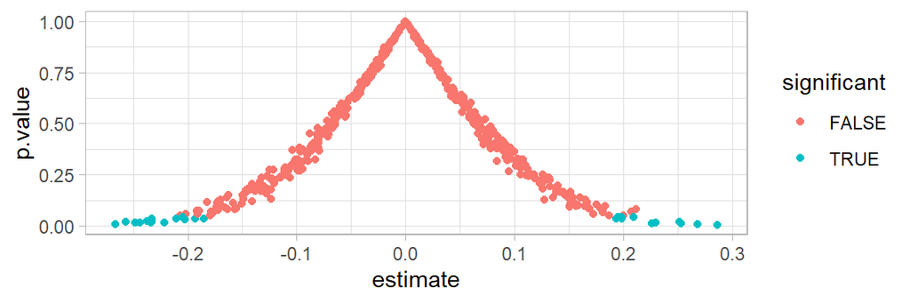

### 1.6.7 Multistage simulation

- Usually a design simulation simulates “from the top”: going from the beginning to the end of the design in each run and repeating
- But sometimes you might want to follow a tree like structure and simulate different steps a different number of times

### 1.6.8 Multistage simulation illustration

Consider for instance this sampling design:

```r
sampling_design <-

  declare_model(N = 500, Y = 1 + rnorm(N, sd = 10)) +
  declare_inquiry(Q = mean(Y)) +
  declare_sampling(S = complete_rs(N = N, n = 100)) +
  declare_estimator(Y ~ 1)
```

### 1.6.9 Multistage simulation illustration

Compare these two diagnoses:

```r
diagnosis_1 <- diagnose_design(sampling_design, sims = c(5000, 1, 1, 1))
diagnosis_2 <- diagnose_design(sampling_design, sims = c(1, 5000, 1, 1))
```

[output not shown]

### 1.6.10 Illustration with tailored estimator and diagnosand

```r
my_estimator <- function(data)
  data.frame(outcome = "Y", estimate = mean(data$Y), std.error = 0)

design <-
  declare_model(N = 5000, Y = rnorm(N)) +
  declare_inquiry(Y_bar_pop = mean(Y, 1)) +
  declare_sampling(S = complete_rs(N = N, n = 500)) +
  declare_inquiry(Y_bar_sample = mean(Y)) +
  declare_estimator(Y ~ 1, inquiry = "Y_bar_pop",label = "ols") +
  declare_estimator(handler = label_estimator(my_estimator),
                    inquiry = "Y_bar_sample",
                    label = "mean")
my_diagnosands <-
  declare_diagnosands(
    bias = mean(estimate - estimand),
    rmse = mean((estimate - estimand)^2)^.5,
    mean_se = mean(std.error))
```

### 1.6.11 Diagnosis

```r
diagnose_design(design, diagnosands = my_diagnosands)
```

| Design | Inquiry | Estimator | Outcome | Term | N Sims | Bias | RMSE | Mean Se |
| --- | --- | --- | --- | --- | --- | --- | --- | --- |
| design | Y_bar_pop | ols | Y | (Intercept) | 500 | 0.00 | 0.04 | 0.04 |
|  |  |  |  |  |  | (0.00) | (0.00) | (0.00) |
| design | Y_bar_sample | mean | Y | NA | 500 | 0.00 | 0.00 | 0.00 |
|  |  |  |  |  |  | (0.00) | (0.00) | (0.00) |

## 1.7 Advanced Redesign

### 1.7.1 Redesign with vector arguments

When redesigning with arguments that are vectors, use `list()` in redesign, with each list item representing a design you wish to create

```r
prob_each <- c(.1, .5, .4)

design_multi  <-
  declare_model(N = 10) +
  declare_assignment(Z = complete_ra(N = N, prob_each = prob_each))

## returns two designs

designs <- design_multi |>
  redesign(prob_each = list(c(.2, .5, .3), c(0, .5, .5)))

designs |> lapply(draw_data)
```

### 1.7.2 Redesign warnings

A parameter has to be called correctly. And you get no warning if you misname.

```r
simplest_design_N  |> redesign(n = 200) |> draw_data() |> nrow()
```

[output not shown]

```
Error: object 'simplest_design_N' not found
```

why not 200?

### 1.7.3 Redesign warnings

A parameter has to be called explicitly

```r
N <- 100

my_N <- function(n = N) n

simplest_design_N2 <-

  declare_model(N = my_N(), Y = rnorm(N)) +
  declare_inquiry(Q = 0) +
  declare_estimator(Y ~ 1)

simplest_design_N2 |> redesign(N = 200) |> draw_data() |> nrow()
```

```
[1] 100
```

why not 200?

### 1.7.4 Redesign warnings

A parameter has to be called explicitly

```r
N <- 100

my_N <- function(n = N) n

simplest_design_N2 <-

  declare_model(N = my_N(N), Y = rnorm(N)) +
  declare_inquiry(Q = 0) +
  declare_estimator(Y ~ 1)

simplest_design_N2 |> redesign(N = 200) |> draw_data() |> nrow()
```

```
[1] 200
```

OK

### 1.7.5 Redesign with a function

Here is an example of redesigning where the “parameter” is a function

```r
new_N <- function(n, factor = 1.31) n*factor

simplest_design_N2 |> redesign(my_N = new_N) |> draw_data() |> nrow()
```

```
[1] 131
```